# 6.caret_meta

Emily Yeo

2024-09-04

#### based on the tutorial : https://topepo.github.io/caret/

#### R markdown guide https://bookdown.org/yihui/rmarkdown/html-document.html

# 2.2 Change scatter

to whatever variables you are interested in looking at

```
## 'data.frame':    154 obs. of  3 variables:
##  $ age                  : num  26.1 21.8 54.9 47.1 39 ...
##  $ class_attend_pct_wk52: num  76.5 28.1 78.1 75 96.9 ...
##  $ final.wt             : num  81.9 95.4 93.9 62.2 86.7 ...
```

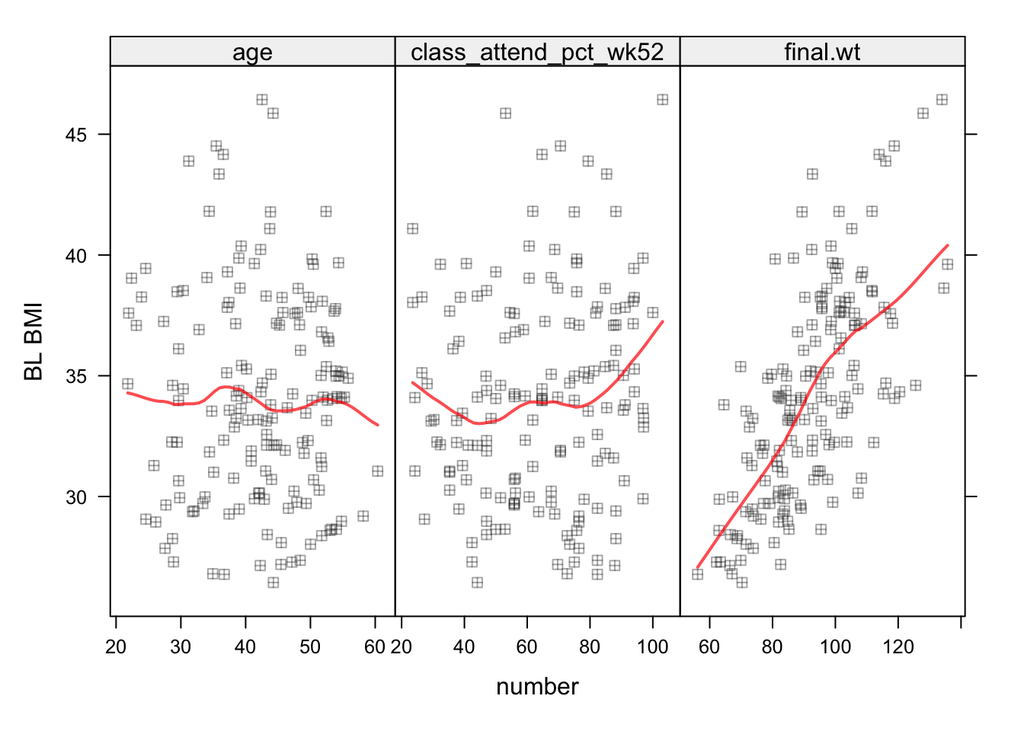

# 3.1 Dummy Vars

The function takes a formula and a data set and outputs an object that can be used to create the dummy variables using the predict method. Note there is no intercept and each factor has a dummy variable for each level, so this parameterization may not be useful for some model functions, such as lm.

```r
dummies <- dummyVars(clin.sig.wtloss.final ~., data = met_n)
head(predict(dummies, newdata = met_n))
```

```
##   met_hdl met_wc met_gluc met_tg met_bp metS cohort pielou_evenness
## 1       1      1        0      0      0    0      1       0.5950297
## 2       1      1        0      0      0    0      3       0.7389432
## 3       0      1        1      0      0    0      3       0.7160737
## 4       1      1        1      1      0    1      3       0.7948804
## 5       0      1        0      1      1    1      3       0.7348399
## 6       1      1        0      0      1    1      3       0.7891130
##   shannon_entropy faith_pd observed_features randomized_group height_inches
## 1        4.073270 5152.958               115                1            67
## 2        4.920040 4604.386               101                1            66
## 3        5.112445 7045.468               141                1            66
## 4        5.699233 5746.011               144                0            61
## 5        5.319068 6272.288               151                0            65
## 6        5.911918 7908.472               180                1            68
##   height_cm      age ucd_employee job_activity sex gender race ethnicity
```

[output cut: 125 more lines]

# 3.2 Zero & near zero predictors

## Code

Code to identify numeric values that are highly unbalanced

```r
data.frame(table(met_n$maintain))
```

```
##   Var1 Freq
## 1    0   36
## 2    1   60
```

Looking at the MDRR data, the nearZeroVar function can be used to identify near zero-variance variables (the saveMetrics argument can be used to show the details and usually defaults to FALSE): By default, nearZeroVar will return the positions of the variables that are flagged to be problematic.

```r
nzv <- nearZeroVar(met_n, saveMetrics= TRUE)
nzv[nzv$nzv,][1:10,]
```

```
##            freqRatio percentUnique zeroVar  nzv
## withdrawal         0     0.6493506    TRUE TRUE
## NA                NA            NA      NA   NA
## NA.1              NA            NA      NA   NA
## NA.2              NA            NA      NA   NA
## NA.3              NA            NA      NA   NA
## NA.4              NA            NA      NA   NA
## NA.5              NA            NA      NA   NA
## NA.6              NA            NA      NA   NA
## NA.7              NA            NA      NA   NA
## NA.8              NA            NA      NA   NA
```

```r
dim(met_n)
```

```
## [1] 154  91
```

```r
nzv <- nearZeroVar(met_n)
filteredDescr <- met_n[, -nzv]
dim(filteredDescr)
```

```
## [1] 154  90
```

```r
setdiff(colnames(met_n), colnames(filteredDescr))
```

```
## [1] "withdrawal"
```

So it seem sthe withdrawal period is something that has unbalanced zeros

## Background

In some situations, the data generating mechanism can create predictors that only have a single unique value (i.e. a “zero-variance predictor”). For many models (excluding tree-based models), this may cause the model to crash or the fit to be unstable. Similarly, predictors might have only a handful of unique values that occur with very low frequencies - also unbalanced.

The concern here that these predictors may become zero-variance predictors when the data are split into cross-validation/bootstrap sub-samples or that a few samples may have an undue influence on the model. These “near-zero-variance” predictors may need to be identified and eliminated prior to modeling.

To identify these types of predictors, the following two metrics can be calculated:

the frequency of the most prevalent value over the second most frequent value (called the “frequency ratio), which would be near one for well-behaved predictors and very large for highly-unbalanced data and the “percent of unique values is the number of unique values divided by the total number of samples (times 100) that approaches zero as the granularity of the data increases If the frequency ratio is greater than a pre-specified threshold and the unique value percentage is less than a threshold, we might consider a predictor to be near zero-variance.

We would not want to falsely identify data that have low granularity but are evenly distributed, such as data from a discrete uniform distribution. Using both criteria should not falsely detect such predictors.

# 3.3 Identifying Correlated Predictors

```r
descrCor <-  cor(filteredDescr)
highCorr <- sum(abs(descrCor[upper.tri(descrCor)]) > .999)
summary(descrCor[upper.tri(descrCor)])
```

```
##    Min. 1st Qu.  Median    Mean 3rd Qu.    Max.    NA's
##  -0.740  -0.061   0.024   0.054   0.105   1.000    3375
```

```r
# wait for imputeted data to do this
#highlyCorDescr <- findCorrelation(descrCor, cutoff = .75)
#filteredDescr <- filteredDescr[,-highlyCorDescr]
#descrCor2 <- cor(filteredDescr)
#summary(descrCor2[upper.tri(descrCor2)])
```

# 3.6 Centering and scaling

### Code

The preProcess option “range” scales the data to the interval between zero and one. Half of the data are used to estimate the location and scale of the predictors. The function preProcess doesnt actually pre-process the data. predict.preProcess is used to pre-process this and other data sets.

```r
data(mdrr)
inTrain <- sample(seq(along = mdrrClass),
                  length(mdrrClass)/2) # random sample of indices to split the data

training <- filteredDescr[inTrain,]
test <- filteredDescr[-inTrain,]
trainMDRR <- mdrrClass[inTrain]
testMDRR <- mdrrClass[-inTrain]

# stores pre-processing parameters for centering (subtracting the mean) and
# scaling (dividing by the standard deviation) the training data.
preProcValues <- preProcess(training, method = c("center", "scale"))

# apply the pre-processing (centering & scaling) to the training & test datasets
trainTransformed <- predict(preProcValues, training)
testTransformed <- predict(preProcValues, test)
```

```r
# Extract the continuous target variable
myTarget <- met_n$outcome_BMI_fnl_12m

# Remove the target column from the features
myData <- met_n[, !names(met_n) %in% "target"]

# Split the data into training and test sets
set.seed(123)  # Set seed for reproducibility
inTrain <- sample(seq(nrow(myData)), size = nrow(myData) / 2)
training <- myData[inTrain,]
test <- myData[-inTrain,]
dim(training)
```

```
## [1] 77 91
```

```r
dim(test)
```

```
## [1] 77 91
```

```r
trainTarget <- myTarget[inTrain]
testTarget <- myTarget[-inTrain]

# Find variables with zero variance
# Remove zero variance columns from the training and test data

# Preprocess the data
preProcValues <- preProcess(training, method = c("center", "scale"))
trainTransformed <- predict(preProcValues, training)
testTransformed <- predict(preProcValues, test)
```

### Background

The preProcess class can be used for many operations on predictors, including centering and scaling. The transformation can be estimated from the training data and applied to any data set with the same variables. The function preProcess estimates the required parameters for each operation and predict.preProcess is used to apply them to specific data sets. This function can also be interfaces when calling the train function.

Several types of techniques are described in the next few sections and then another example is used to demonstrate how multiple methods can be used. Note that, in all cases, the preProcess function estimates whatever it requires from a specific data set (e.g. the training set) and then applies these transformations to any data set without recomputing the values